# Business statics mid term assignment

22433694

This is to certify that the work I am submitting is my own. All external references and sources are clearly acknowledged and identified within the contents. I am aware of the University of Warwick regulation concerning plagiarism and collusion.

No substantial part(s) of the work submitted here has also been submitted by me in other assessments for accredited courses of study, and I acknowledge that if this has been done an appropriate reduction in the mark I might otherwise have received will be made .

# Section 1

- This report fulfills the requests of Analyzing information on children living in low-income households.
- The information is arranged in London based on geographic areas.
- The vast regions that make up London’s boroughs are normally overseen by separate wards.
- There are wards, which are additional subdivisions, inside every borough.
- The 8-year data set offers a historical perspective.
- It keeps track of how many children reside in low Income in each London ward.

## Data Dictionary

The variables in the dataset are described in the table below

| Variable | Description |
| --- | --- |
| Ward.code | Code of different wards exists in London |
| Wards..2018 | Name of different wards in London |
| year | Different years along which the data has been taken |
| Borough | Name of Different Borough in london |
| children | Average number of children |

## Read Data

```r
dataset=read.csv("children_low_income_data.csv")
#Year has been taken as integer here so we have to convert it into factor
dataset$year=as.factor(dataset$year)
```

## Calculating Mean , Standard deviation , Minimum and Maximum number of Children foror each Borough

```r
dataset_processed1 <- dataset %>%
  group_by(Borough) %>%
  summarise(avg_children_in_Borough=mean(children,na.rm=TRUE),sd_children_in_Borough=sd(children,na.rm=TRUE),min_children_in_Borough=min(children,na.rm=TRUE),max_children_in_Borugh=max(children,na.rm=TRUE))
```

## Excluding Usual Borough

##### Some of the Boroughs have Null values in them so removing them for further analysis

```r
dataset_processed <- dataset %>%
  filter(!Borough%in%c("City of London", "Kensington and Chelsea", "Kingston upon Thames", "Richmond upon Thames", "Westminster"))
```

## Calculating Mean and Standard deviation Then Plotting it

```r
dataset_With_Mean_Average <- dataset_processed%>%
  group_by(year) %>%
  summarise(children_average=mean(children),children_sd=sd(children))
```

## Plotting the graph for Year Vs Average number of children in low income household

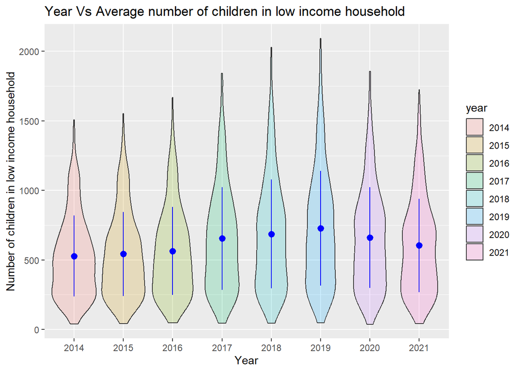

```r
ggplot(dataset_processed,aes(factor(year),children,fill=year))+geom_violin(alpha=0.2) + geom_pointrange(data = dataset_With_Mean_Average, aes(x = factor(year), y = children_average, ymin = children_average - children_sd, ymax =children_average + children_sd), color = "blue", size = 0.5,show.legend=FALSE)+labs(x="Year",y="Number of children in low income household") + ggtitle("Year Vs Average number of children in low income household")
```

## Performing t-test for year 2014 and 2021

```r
dataset_test<- dataset_processed %>%
  filter((year==2014 | year==2021) & !is.na(children)  )
t.test(dataset_test$children[dataset_test$year==2021],dataset_test$children[dataset_test$year==2014])
```

```
##
##  Welch Two Sample t-test
##
## data:  dataset_test$children[dataset_test$year == 2021] and dataset_test$children[dataset_test$year == 2014]
## t = 4.0215, df = 1095.2, p-value = 6.18e-05
## alternative hypothesis: true difference in means is not equal to 0
## 95 percent confidence interval:
##   38.6873 112.4091
## sample estimates:
## mean of x mean of y
##  603.8696  528.3214
```

## Estimating the results and calculating confidence intervals

```r
(dataset_children_by_year <- lm(dataset_test$children~dataset_test$year))
```

```
##
## Call:
## lm(formula = dataset_test$children ~ dataset_test$year)
##
## Coefficients:
##           (Intercept)  dataset_test$year2021
##                528.32                  75.55
```

```r
dataset_children_by_year_emm <- emmeans(dataset_children_by_year,~factor(year))
(dataset_children_by_year_contrast<-confint(pairs(dataset_children_by_year_emm)))
```

```
##  contrast            estimate   SE   df lower.CL upper.CL
##  year2014 - year2021    -75.5 18.8 1118     -112    -38.7
##
## Confidence level used: 0.95
```

```r
#the mean for children for low income household for 2014 is 528 , and the confidence intervals 95 percent CI[502,554]. and for 2021 the mean is 604 and the confidence intervals 95 percent CI[578,630]
#according to t test the mean difference for number of children is 76 and 95 percent confidence interval [-112,-38.7] lesser in comparison to the year 2014 than 2021 and is significantly different from zero with t(1095)=-4.02 with p value less than 0.05
```

## Plotting Confidence Intervals

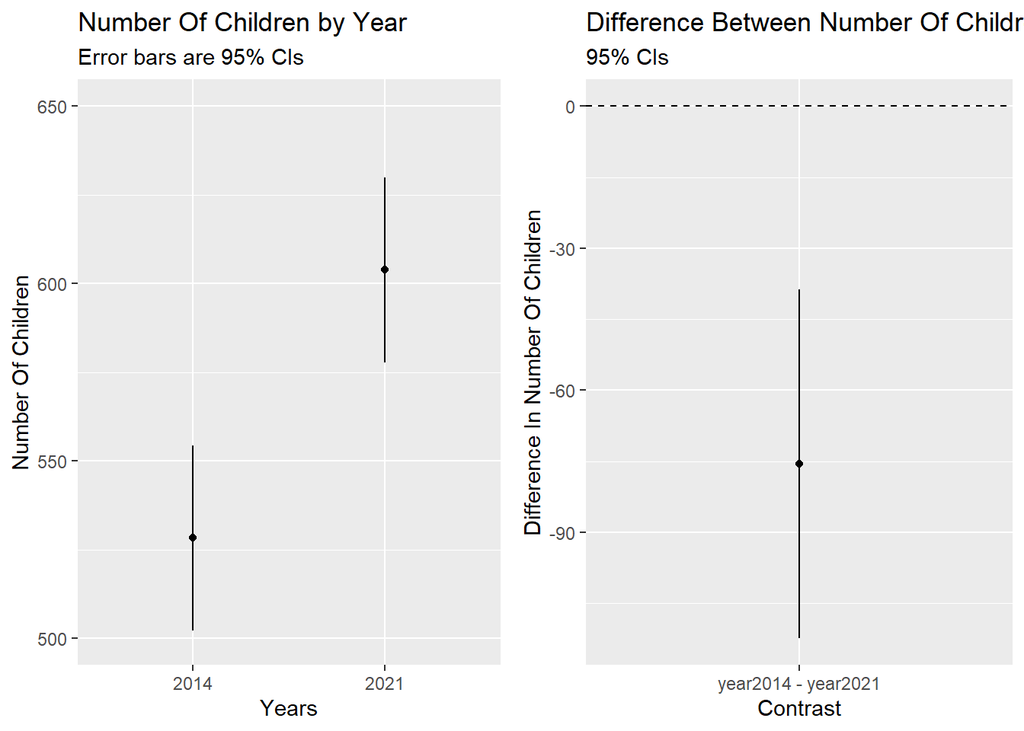

```r
grid.arrange(
    ggplot(summary(dataset_children_by_year_emm), aes(x=factor(year), y=emmean, ymin=lower.CL, ymax=upper.CL)) +
        geom_point() + geom_linerange() +
        labs(y="Number Of Children", x="Years", subtitle="Error bars are 95% CIs", title="Number Of Children by Year") + ylim(500,650),
    ggplot(dataset_children_by_year_contrast, aes(x=contrast, y=estimate, ymin=lower.CL, ymax=upper.CL)) +
        geom_point() + geom_linerange() +
        labs(y="Difference In Number Of Children", x="Contrast", subtitle="95% CIs", title="Difference Between Number Of Children")  +
        geom_hline(yintercept=0, lty=2),
    ncol=2
)
```

“The mean for number of children in 2014 is 528 and 95% CI [502,554]. The mean for number of children in 2021 is 604 and 95% CI [578,630]. The difference is -75.5 and 95% CI [-112,-38.7]”

# Section 2

## Report

This report shows the analysis asked by the company that we have **5120** number of observations which have total of 5 variables which are **Ward.code** , **Wards..2018**, **year** , **Borough** and **children** . After that the unusual boroughs are removed which are **City of London**, **Kensington and Chelsea** , **Kingston upon Thames** , **Richmond upon Thames** and **Westminster** . Upon analysis these borough are the one which have null values and have unusual number of children which are removed . Then mean and standard deviation of the data is calculated which is as follows

**Children average and Standard deviation**

| year | children_average | children_sd |
| --- | --- | --- |
| 2014 | 528.3214 | 290.7796 |
| 2015 | 543.0018 | 301.7581 |
| 2016 | 564.4679 | 317.1347 |
| 2017 | 654.8929 | 368.9300 |
| 2018 | 686.6304 | 391.1880 |
| 2019 | 726.8071 | 411.9014 |
| 2020 | 660.8875 | 362.4272 |
| 2021 | 603.8696 | 336.2769 |

We can see that the mean was lowest in 2014 and then it substantially increased in the year 2019. Afterward, the plotting of data was done on a violin plot in which the plotting was done against the number of children in low-income household vs year along with the mean and standard deviation which is as follows

**Children average and Standard deviation for each Borough**

| Borough | avg_children_in_Borough | sd_children_in_Borough | min_children_in_Borough | max_children_in_Borugh |
| --- | --- | --- | --- | --- |
| Barking and Dagenham | 987.06618 | 259.00079 | 551 | 1750 |
| Barnet | 588.04167 | 340.07701 | 116 | 1807 |
| Bexley | 506.03676 | 246.11281 | 174 | 1469 |
| Brent | 707.53571 | 280.63079 | 249 | 1578 |
| Bromley | 390.25568 | 210.68050 | 113 | 1062 |
| Camden | 451.67361 | 268.40122 | 78 | 1373 |
| City of London | 26.48387 | 31.75833 | 5 | 156 |
| Croydon | 570.49554 | 315.04882 | 48 | 1508 |
| Ealing | 639.80978 | 313.80022 | 128 | 1327 |
| Enfield | 738.44048 | 408.98639 | 193 | 1895 |
| Greenwich | 839.75735 | 407.58051 | 211 | 1723 |
| Hackney | 697.01190 | 288.34265 | 231 | 1803 |
| Hammersmith and Fulham | 315.83594 | 199.42100 | 45 | 1042 |
| Haringey | 634.47368 | 407.23929 | 95 | 1691 |
| Harrow | 440.57143 | 179.35311 | 156 | 909 |
| Havering | 516.88889 | 276.25516 | 152 | 1405 |
| Hillingdon | 552.54545 | 336.78853 | 117 | 1416 |
| Hounslow | 599.03125 | 252.99304 | 141 | 1230 |
| Islington | 487.51562 | 149.59757 | 265 | 937 |
| Kensington and Chelsea | 146.72917 | 134.79968 | 23 | 557 |
| Kingston upon Thames | 236.37500 | 111.33478 | 69 | 665 |
| Lambeth | 584.58929 | 202.96861 | 212 | 1247 |
| Lewisham | 729.09722 | 258.80858 | 351 | 1570 |
| Merton | 379.50625 | 269.20675 | 38 | 1055 |
| Newham | 1213.26250 | 250.24329 | 575 | 1987 |
| Redbridge | 689.31818 | 323.07063 | 133 | 1664 |
| Richmond upon Thames | 163.38889 | 93.76187 | 58 | 507 |
| Southwark | 563.40217 | 278.93365 | 108 | 1279 |
| Sutton | 329.43056 | 153.47830 | 122 | 802 |
| Tower Hamlets | 1035.50625 | 449.15133 | 218 | 2094 |
| Waltham Forest | 797.10625 | 256.33038 | 269 | 1448 |
| Wandsworth | 392.20000 | 259.62396 | 85 | 1429 |
| Westminster | 259.85625 | 228.65832 | 16 | 853 |

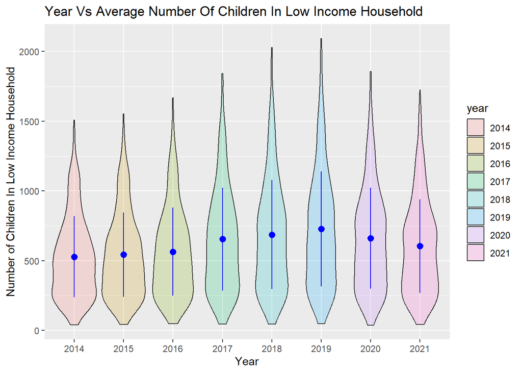

The blue dot represents the mean and the line represents the maximum and minimum standard deviation

The graph clearly shows the bulges in the middle showing a large number of data points in the middle region for Each Year indicating a huge number of children .

###### Reference

- www.stackoverflow.com
- www.datacamp.com
- Lecture Resources
- R for Data Science Garrett Grolemund (Author), Hadley Wickham (Author)
- Sample Assignment